# White wine qualities exploration by Wu Qihua

# 单变量绘图选择

```
## 'data.frame':    4898 obs. of  13 variables:
##  $ X                   : int  1 2 3 4 5 6 7 8 9 10 ...
##  $ fixed.acidity       : num  7 6.3 8.1 7.2 7.2 8.1 6.2 7 6.3 8.1 ...
##  $ volatile.acidity    : num  0.27 0.3 0.28 0.23 0.23 0.28 0.32 0.27 0.3 0.22 ...
##  $ citric.acid         : num  0.36 0.34 0.4 0.32 0.32 0.4 0.16 0.36 0.34 0.43 ...
##  $ residual.sugar      : num  20.7 1.6 6.9 8.5 8.5 6.9 7 20.7 1.6 1.5 ...
##  $ chlorides           : num  0.045 0.049 0.05 0.058 0.058 0.05 0.045 0.045 0.049 0.044 ...
##  $ free.sulfur.dioxide : num  45 14 30 47 47 30 30 45 14 28 ...
##  $ total.sulfur.dioxide: num  170 132 97 186 186 97 136 170 132 129 ...
##  $ density             : num  1.001 0.994 0.995 0.996 0.996 ...
##  $ pH                  : num  3 3.3 3.26 3.19 3.19 3.26 3.18 3 3.3 3.22 ...
##  $ sulphates           : num  0.45 0.49 0.44 0.4 0.4 0.44 0.47 0.45 0.49 0.45 ...
##  $ alcohol             : num  8.8 9.5 10.1 9.9 9.9 10.1 9.6 8.8 9.5 11 ...
##  $ quality             : int  6 6 6 6 6 6 6 6 6 6 ...
```

```
##        X        fixed.acidity    volatile.acidity  citric.acid
##  Min.   :   1   Min.   : 3.800   Min.   :0.0800   Min.   :0.0000
##  1st Qu.:1225   1st Qu.: 6.300   1st Qu.:0.2100   1st Qu.:0.2700
##  Median :2450   Median : 6.800   Median :0.2600   Median :0.3200
##  Mean   :2450   Mean   : 6.855   Mean   :0.2782   Mean   :0.3342
##  3rd Qu.:3674   3rd Qu.: 7.300   3rd Qu.:0.3200   3rd Qu.:0.3900
##  Max.   :4898   Max.   :14.200   Max.   :1.1000   Max.   :1.6600
##  residual.sugar     chlorides       free.sulfur.dioxide
##  Min.   : 0.600   Min.   :0.00900   Min.   :  2.00
##  1st Qu.: 1.700   1st Qu.:0.03600   1st Qu.: 23.00
##  Median : 5.200   Median :0.04300   Median : 34.00
##  Mean   : 6.391   Mean   :0.04577   Mean   : 35.31
##  3rd Qu.: 9.900   3rd Qu.:0.05000   3rd Qu.: 46.00
##  Max.   :65.800   Max.   :0.34600   Max.   :289.00
##  total.sulfur.dioxide    density             pH          sulphates
##  Min.   :  9.0        Min.   :0.9871   Min.   :2.720   Min.   :0.2200
##  1st Qu.:108.0        1st Qu.:0.9917   1st Qu.:3.090   1st Qu.:0.4100
##  Median :134.0        Median :0.9937   Median :3.180   Median :0.4700
##  Mean   :138.4        Mean   :0.9940   Mean   :3.188   Mean   :0.4898
##  3rd Qu.:167.0        3rd Qu.:0.9961   3rd Qu.:3.280   3rd Qu.:0.5500
##  Max.   :440.0        Max.   :1.0390   Max.   :3.820   Max.   :1.0800
##     alcohol         quality
##  Min.   : 8.00   Min.   :3.000
##  1st Qu.: 9.50   1st Qu.:5.000
##  Median :10.40   Median :6.000
##  Mean   :10.51   Mean   :5.878
##  3rd Qu.:11.40   3rd Qu.:6.000
##  Max.   :14.20   Max.   :9.000
```

数据集中一共有13个变量（排除编号X是12个）以及4898个观察样本，在单变量探索中将对12个可用的变量进行分析，其中：

1、fixed.acidity：非挥发性酸，单位是g/dm/^3

2、volatile.acidity：挥发性酸，单位是g/dm^3

3、citric.acid：柠檬酸，单位是g/dm^3

4、residual.sugar：残留糖分，单位是g/dm^3

5、chlorides：氯化物即盐分，单位是g/dm^3

6、free.sulfur.dioxide：游离二氧化硫，单位是mg/dm/^3

7、total.sulfur.dioxide：总二氧化硫，单位是mg/dm^3

8、density：密度，单位是g/dm/^3

9、pH：酸碱度，范围是0~14

10、sulphates：硫酸盐，单位是g/dm^3

11、alcohol：酒精含量，单位是%

12、quality：质量评分，范围是0~10

### 1、fixed.acidity：非挥发性酸

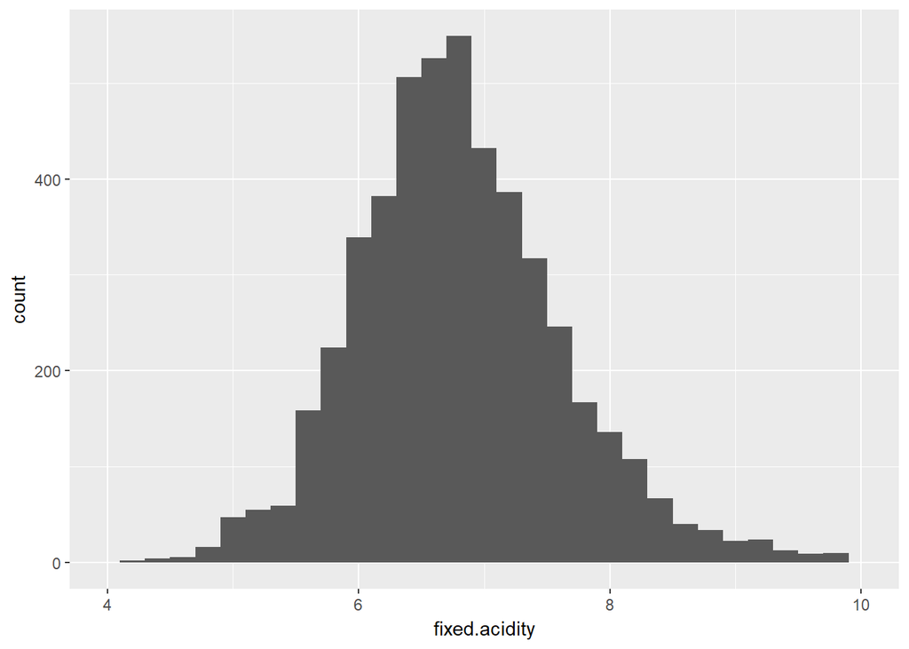

```
##    Min. 1st Qu.  Median    Mean 3rd Qu.    Max.
##   3.800   6.300   6.800   6.855   7.300  14.200
```

调整范围后，从直方图可以看出非挥发性酸变量的分布呈正态分布，绝大部分数据在4~10之间，峰值在6.8附近。

### 2、volatile.acidity：挥发性酸

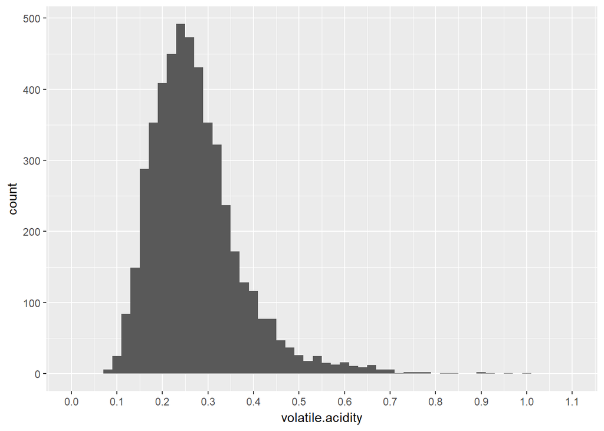

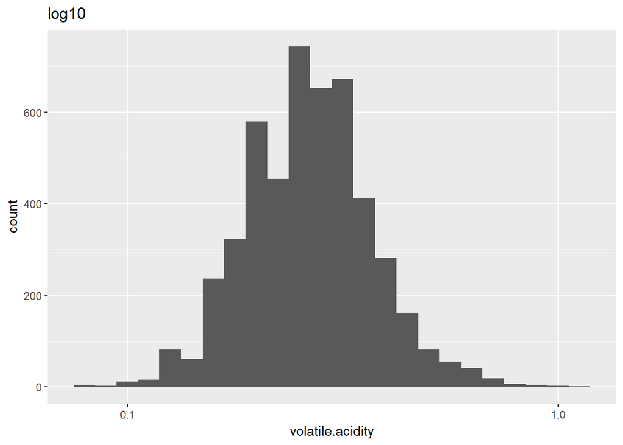

```
##    Min. 1st Qu.  Median    Mean 3rd Qu.    Max.
##  0.0800  0.2100  0.2600  0.2782  0.3200  1.1000
```

此外，可以通过对数据进行对数变换和调整组距，可以观察到第二个图的大体正态分布情况。

### 3、citric.acid：柠檬酸

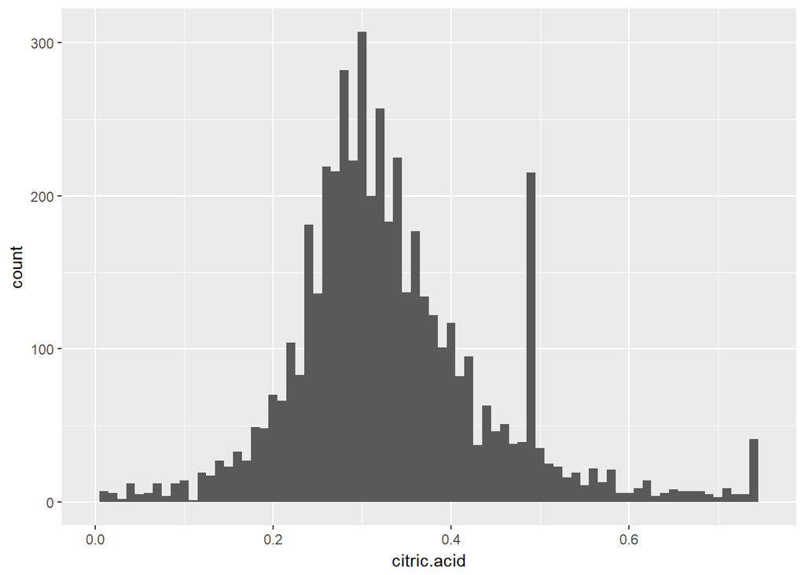

```
##    Min. 1st Qu.  Median    Mean 3rd Qu.    Max.
##  0.0000  0.2700  0.3200  0.3342  0.3900  1.6600
```

```
##
##    0 0.01 0.02 0.03 0.04 0.05 0.06 0.07 0.08 0.09  0.1 0.11 0.12 0.13 0.14
##   19    7    6    2   12    5    6   12    4   12   14    1   19   17   27
## 0.15 0.16 0.17 0.18 0.19  0.2 0.21 0.22 0.23 0.24 0.25 0.26 0.27 0.28 0.29
##   23   33   27   49   48   70   66  104   83  181  136  219  216  282  223
##  0.3 0.31 0.32 0.33 0.34 0.35 0.36 0.37 0.38 0.39  0.4 0.41 0.42 0.43 0.44
##  307  200  257  183  225  137  177  134  122  101  117   82   95   37   63
## 0.45 0.46 0.47 0.48 0.49  0.5 0.51 0.52 0.53 0.54 0.55 0.56 0.57 0.58 0.59
##   46   51   38   39  215   35   25   23   16   19   11   22   13   21    6
##  0.6 0.61 0.62 0.63 0.64 0.65 0.66 0.67 0.68 0.69  0.7 0.71 0.72 0.73 0.74
##    6    9   14    4    6    8    7    7    7    5    3    9    5    5   41
## 0.78 0.79  0.8 0.81 0.82 0.86 0.88 0.91 0.99    1 1.23 1.66
##    2    2    2    2    2    1    1    2    1    5    1    1
```

在调整范围后的直方图，可以看出分布整体呈正太分布，峰值在0.3，但有两个异常值。

但通过统计可以看出异常值是0.49和0.74，推测与葡萄酒的规格有关，可能是某种规格的葡萄酒的柠檬酸含量不能超过0.5或0.75g/dm^3 。

### 4、residual.sugar：残留糖分

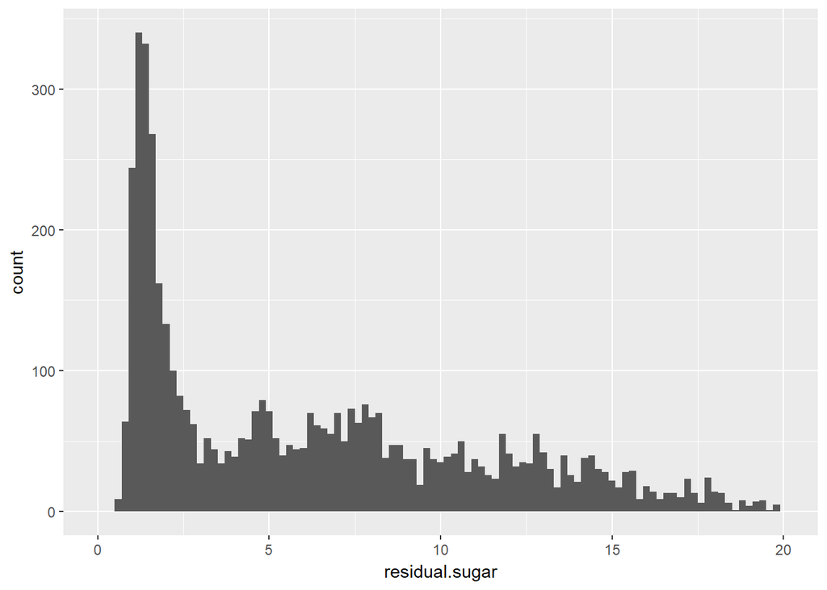

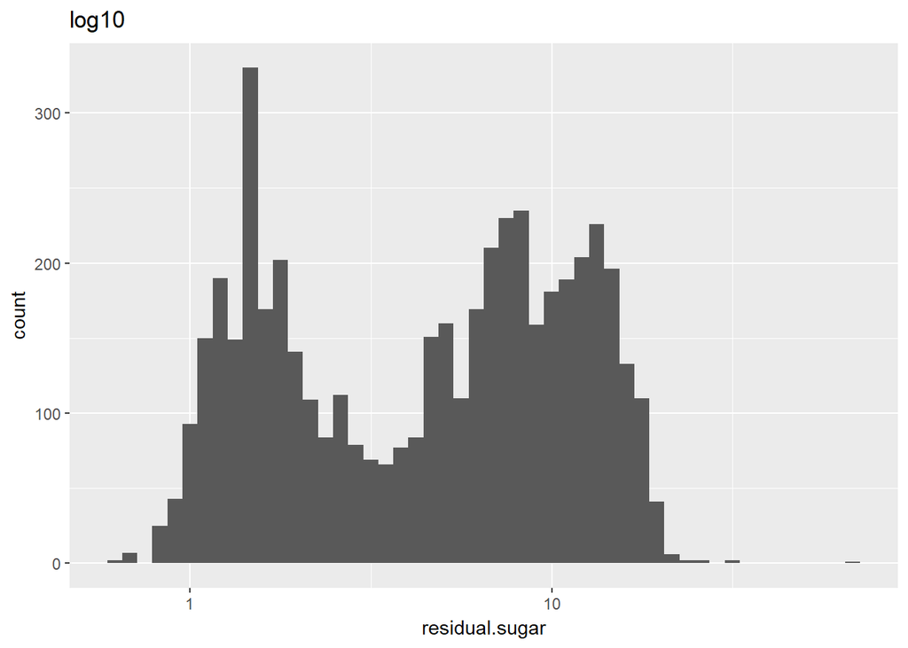

```
##    Min. 1st Qu.  Median    Mean 3rd Qu.    Max.
##   0.600   1.700   5.200   6.391   9.900  65.800
```

如果对数据进行对数转换，从第二个直方图可以看到双峰的结构。

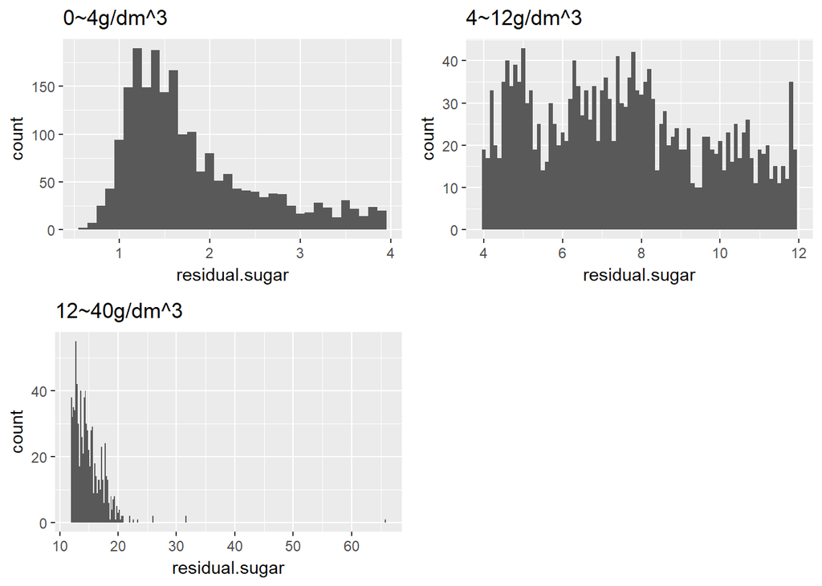

为了解释这现象，若对葡萄酒的制作深入了解，葡萄酒可通过糖分来分类可以分成干葡萄酒（糖分少于4g/dm^3 ），半干葡萄酒（糖分含量4~12g/dm/^3 ）,半甜葡萄酒（糖分含量12~40g/dm^3 ）和甜葡萄酒(糖分大于40g/dm^3 )。

因此我决定创建新变量variety，根据residual.sugar分类，residual.sugar小于4为dry即干白葡萄酒，4到12为semi-dry即半干白葡萄酒，大于等于12为not-dry即非干白葡萄酒。

因此第一个直方图其实是多种品种葡萄酒的糖分含量分布的组合，进行分类后即对糖分数据范围进行限制，可以更详细看出各品种葡萄酒的糖分分布形态。

### 5、chlorides：盐分

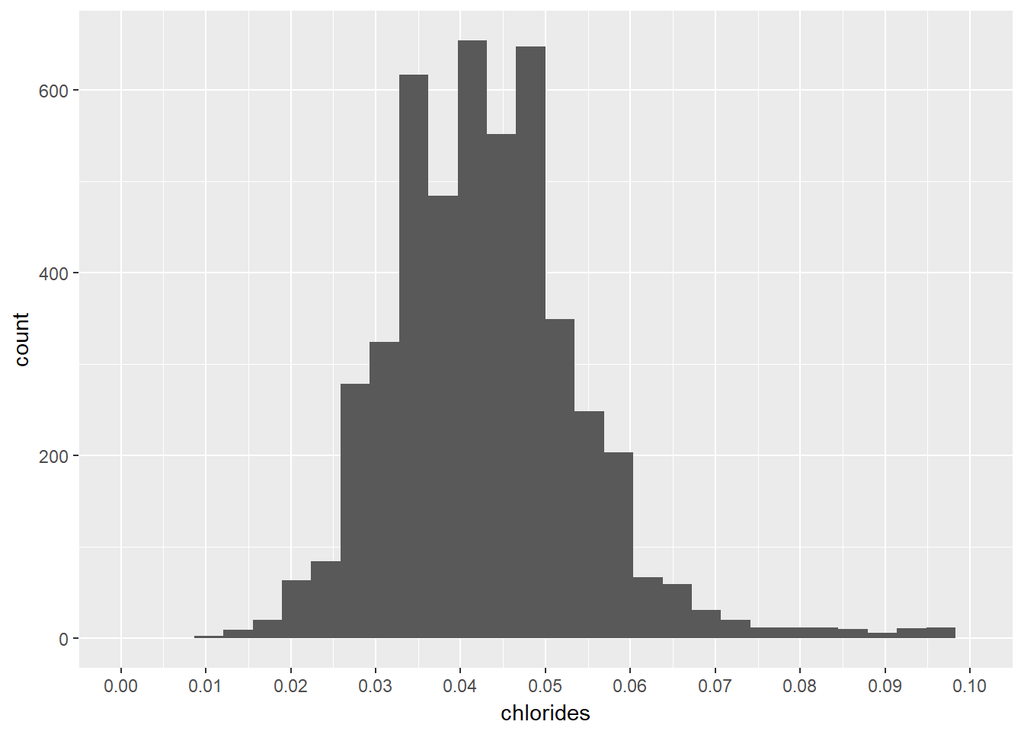

```
##    Min. 1st Qu.  Median    Mean 3rd Qu.    Max.
## 0.00900 0.03600 0.04300 0.04577 0.05000 0.34600
```

通过统计可见盐分数据有较多偏离值，调整范围后可见直方图在0~0.1的范围内呈正态分布，峰值在0.04附近。

### 6、free.sulfur.dioxide：游离二氧化硫

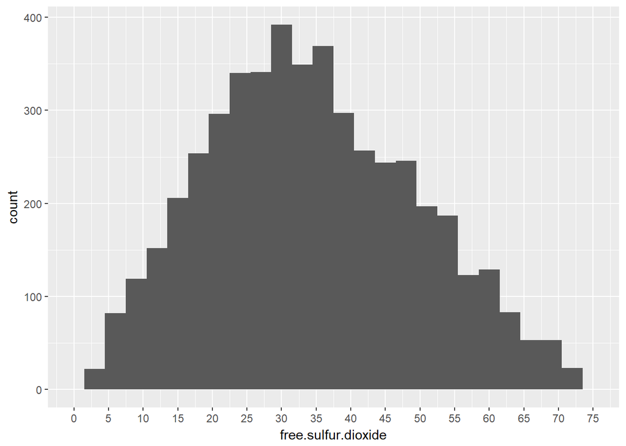

```
##    Min. 1st Qu.  Median    Mean 3rd Qu.    Max.
##    2.00   23.00   34.00   35.31   46.00  289.00
```

调整范围忽略部分偏离值后，从直方图可见游离二氧化硫的数据大体呈正态分布，绝大部分数据在0~75之间，峰值在30附近。

### 7、total.sulfur.dioxide：总二氧化硫

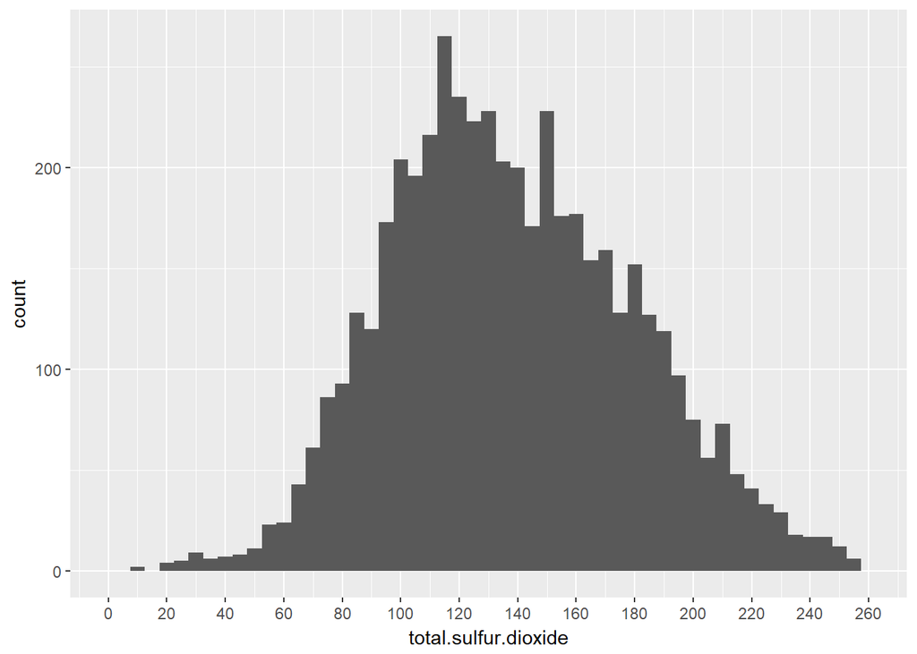

```
##    Min. 1st Qu.  Median    Mean 3rd Qu.    Max.
##     9.0   108.0   134.0   138.4   167.0   440.0
```

调整范围忽略部分偏离值后，从直方图可见总二氧化硫的数据大体呈正态分布，绝大部分数据在0~260之间，峰值在120附近。

### 8、density：密度

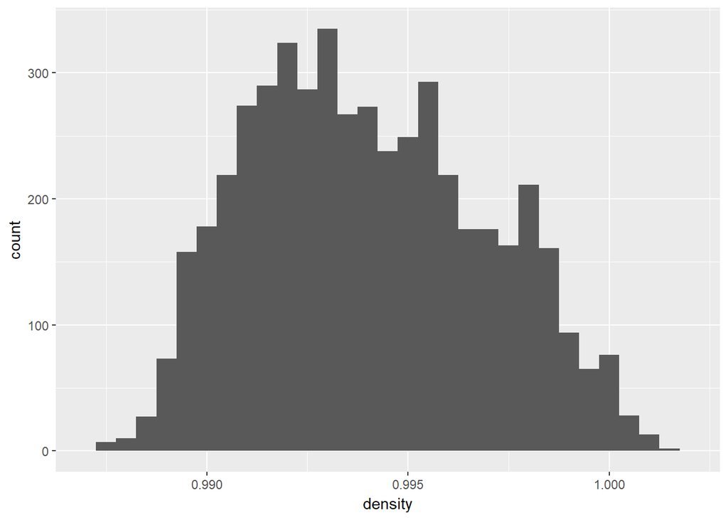

```
##    Min. 1st Qu.  Median    Mean 3rd Qu.    Max.
##  0.9871  0.9917  0.9937  0.9940  0.9961  1.0390
```

密度数据的集中度非常高，从直方图中可以看出其大体的正态分布，绝大部分数据在0.987~1.002之间，峰值在0.993附近。